# Meteorites

Anna Reynolds

2019-07-28

## Overview

This week’s #TidyTuesday dataset is all about meteorites, where they fell and when they fell! Data comes from the Meteoritical Society by way of NASA.

## Load data

```r
library(tidyverse)
#meteorites <- readr::read_csv("https://raw.githubusercontent.com/rfordatascience/tidytuesday/master/data/2019/2019-06-11/meteorites.csv")
#Output the tidy dataset for future use.
#write.csv(meteorites, file = "meteorites.csv")
meteorites <- read_csv("meteorites.csv")
```

## Analysis/visualization

Focus on those that fell on Australia.

```r
met_aus <- filter(meteorites, lat < -11 & lat > -47 & long > 110 & long < 160)
library(leaflet)
leaflet(data = met_aus) %>% addTiles() %>%
  addMarkers(~long, ~lat, popup = ~as.character(name), label = ~as.character(mass))
```

[interactive chart not shown]

```r
pal <- colorFactor(c("blue", "purple"), domain = c("Fell", "Found"))

leaflet(met_aus) %>% addTiles() %>%
  addCircleMarkers(
    radius = ~ifelse(fall == "Found", 6, 10),
    color = ~pal(fall),
    stroke = FALSE, fillOpacity = 0.5, popup = ~paste(name, fall, mass)
  ) %>%
  addLegend(pal = pal, values = ~fall, opacity = 1)
```

[interactive chart not shown]

```r
leaflet(met_aus) %>% addTiles() %>% addCircles(radius = ~mass/100, weight = 1, color = "#777777",
        fillColor = ~pal(mass), fillOpacity = 0.7, popup = ~paste(mass))
```

[interactive chart not shown]

Make a static map showing those that fell on Australia.

```r
library(rnaturalearth)
library(rnaturalearthdata)
library(sf)
```

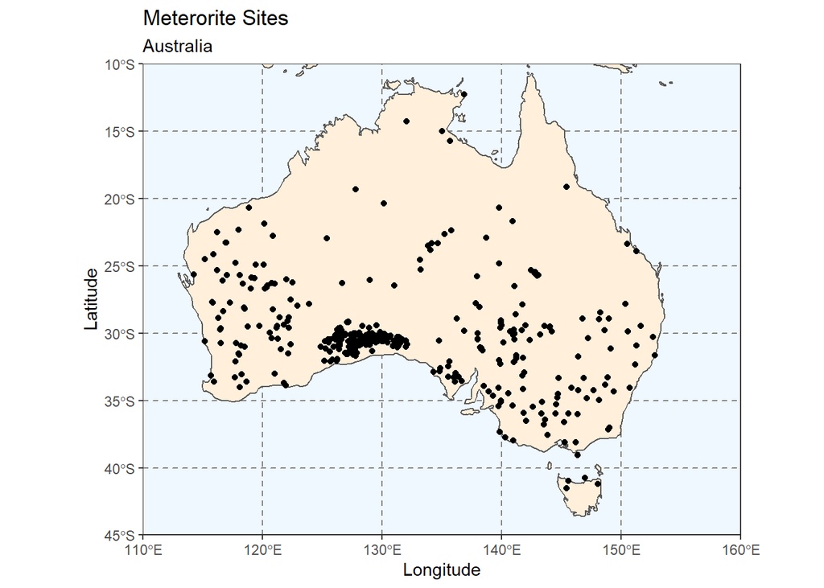

```r
world <- ne_countries(scale = "medium", returnclass = "sf")
sites <- st_as_sf(met_aus, coords = c("long", "lat"),
    crs = 4326, agr = "constant")
ggplot(data = world) +
    geom_sf(fill = "antiquewhite1") +
    geom_sf(data = sites) +
    coord_sf(xlim = c(110, 160), ylim = c(-10, -45), expand = FALSE) + theme_bw() +
    xlab("Longitude") + ylab("Latitude") +
    ggtitle("Meterorite Sites", subtitle = "Australia") +
    theme(panel.grid.major = element_line(color = gray(0.5), linetype = "dashed",
        size = 0.5), panel.background = element_rect(fill = "aliceblue"))
```

Add map of Australia including the States.

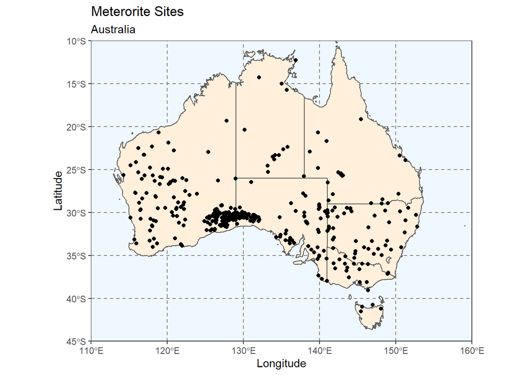

```r
oz_shape <- rnaturalearth::ne_states(geounit = "australia")
# convert to simple features
oz_shape_sf <- sf::st_as_sf(oz_shape)
ggplot(oz_shape_sf) +
    geom_sf(fill = "antiquewhite1") +
    geom_sf(data = sites) +
    coord_sf(xlim = c(110, 160), ylim = c(-10, -45), expand = FALSE) + theme_bw() +
    xlab("Longitude") + ylab("Latitude") +
    ggtitle("Meterorite Sites", subtitle = "Australia") +
    theme(panel.grid.major = element_line(color = gray(0.5), linetype = "dashed",
        size = 0.5), panel.background = element_rect(fill = "aliceblue"))
```

## Results

- Most of the meteorites in Australia in the database are recorded as being found.
- There is a cluster of meteorites recorded along the Great Australian Bight.
- The largest meteorite recorded was in South-eastern corner of Western Australia.

## Discussion/conclusions

Leaflet is a good package to use to explore the data but zooming in/out is very sensitive with a trackpad. It also requires an internet connection.

## Package citations

Hadley Wickham (2017). tidyverse: Easily Install and Load the ‘Tidyverse’. R package version 1.2.1. https://CRAN.R-project.org/package=tidyverse

Joe Cheng, Bhaskar Karambelkar and Yihui Xie (2018). leaflet: Create Interactive Web Maps with the JavaScript ‘Leaflet’ Library. R package version 2.0.1. https://CRAN.R-project.org/package=leaflet

Andy South (2017). rnaturalearth: World Map Data from Natural Earth. R package version 0.1.0. https://CRAN.R-project.org/package=rnaturalearth

Pebesma, E., 2018. Simple Features for R: Standardized Support for Spatial Vector Data. The R Journal 10 (1), 439-446, https://doi.org/10.32614/RJ-2018-009